# Ex 13 Probability

## 13.1 Exercises Discrete Probability

### 13.1.1 Qn

> 1. One bead will be drawn at random from a box containing: 3 cyan beads, 5 magenta beads, and 7 yellow beads. What is the probability that the bead will be cyan?

It is helpful to keep the following thought from the book in mind, while working on the exercises:  
“*A more tangible way to think about the probability of an event is as the **proportion** of times the event occurs when we repeat the experiment an infinite number of times, independently, and under the same conditions.*”

The cyan bead proportion is 20% or 3/15=1/5.  
The experiment is showing the theoretical prediction.  
First create the bead structure by using the function `rep`.

```r
beads <- rep(c("cyan", "magenta", "yellow"), times = c(3,5,7))
```

Then we make random draw with `sample` and repeat the random draw with `replicate` for a large number of times (B), then we evaluate the result with `prop.table`. The function `replicate` is a wrapper for the function `sapply` for the repeated evaluation of an expression (it has nothing in common with the previously used function `rep`).

```r
set.seed(1986)
B <- 10000
events <- replicate(B, sample(beads, 2))
tab <- table(events)
prop.table(tab)
```

```
## events
##    cyan magenta  yellow
## 0.19695 0.33255 0.47050
```

Alternatively, we can utilize the parameters of the function `sample` to create a large number of draws directly. The result is the same.

```r
set.seed(1986)
B <- 10000
events <- sample(beads, B, replace = TRUE)
prop.table(table(events))
```

```
## events
##    cyan magenta  yellow
##  0.1973  0.3333  0.4694
```

### 13.1.2 Qn

> 2. What is the probability that the bead will not be cyan?

The proportion is 1-1/5=4/5, which is 80%. See experiment in question 1).

### 13.1.3 Qn

> 3. Instead of taking just one draw, consider taking two draws. You take the second draw without returning the first draw to the box. We call this sampling **without** replacement. What is the probability that the first draw is cyan and that the second draw is not cyan?

The proportion of the first draw being cyan is 1/5 or 20%. Then the proportion of the second draw will be with a collection of just 14 beads of which 2 are cyan and 12 being not cyan. Therefore the proportion that the second draw will be not cyan is 12/14=6/7 or about 86%.

We can validate these conceptual thoughts by conducting an experiment utilizing the following equation.

Where the condition $A=$ “the first draw is cyan” and $B=$ “the second draw is not cyan”.

$$\mbox{Pr}(B|A) = \frac{\mbox{Pr}(A \mbox{ and } B)} { \mbox{Pr}(A)}$$

The replicate function creates a matrix with the first row carrying all first draws and the second row all second draws.

```r
set.seed(1986)
B <- 100000
cyan <- "cyan"
perms <- replicate(B,sample(beads,2))
first_draw <- perms[1,]
second_draw <- perms[2,]
sum(first_draw %in% cyan & !second_draw %in% cyan)/sum(first_draw %in% cyan)
```

```
## [1] 0.8549127
```

Here, the experimental result of 85,50% is slightly off of the predicted result, because the number of repetitions of the random draw was not infinite but limited to a small number.  
If we would increase the number of draws the value would converge to the predicted value.

### 13.1.4 Qn

> 4. Now repeat the experiment, but this time, after taking the first draw and recording the color, return it to the box and shake the box. We call this sampling **with** replacement. What is the probability that the first draw is cyan and that the second draw is not cyan?

First let’s think what result can be expected.  
Again, the proportion of a draw being “cyan” is A=0.2 or 20% and the proportion of not being “cyan” is B=0.8 or 80%.  
Since we are putting the bead from the first draw back in the bag and performing another draw, both draws are independent of each other.  
Therefore, the following equation can be applied and showing that only the proportion of the last draw counts.

$$\mbox{Pr}(B|A) = \frac{\mbox{Pr}(A \mbox{ and } B)} { \mbox{Pr}(A)} = \frac{\mbox{Pr}(A) \mbox{Pr}(B)} { \mbox{Pr}(A)} = \mbox{Pr}(B)$$

To answer this question we use the same functions but this time we utelize the parameter `replace=TRUE` from the `sample` function.

```r
set.seed(1986)
B <- 100000
cyan <- "cyan"
perms <- replicate(B,sample(beads,2,replace = TRUE))
first_draw <- perms[1,]
second_draw <- perms[2,]
sum(first_draw %in% cyan & !second_draw %in% cyan)/sum(first_draw %in% cyan)
```

```
## [1] 0.8007709
```

Again, by increasing the number of possible permutations in the Monte Carlo experiment, the value will converge towards the predicted value.

### 13.1.5 Qn

> 5. Two events $A$ and $B$ are independent if $\mbox{Pr}(A \mbox{ and } B) = \mbox{Pr}(A) Pr(B)$. Under which situation are the draws independent?

>    A. You don’t replace the draw.

>    B. You replace the draw.

>    C. Neither

>    D. Both

Answer B.  
After replacing the draw the state of the system is in its initial state and the number of possible draws stays the same.  
Threfore, you cannot distinguish if the event $4$ has taken place before or after event $B$ and vise versa. Howerver, if you do not replace the draw, then after each draw the state of the system changes and the number of possible draws is reduced.

### 13.1.6 Qn

> 6. Say you’ve drawn 5 beads from the box, with replacement, and all have been yellow. What is the probability that the next one is yellow?

Since we draw our beads with replacement the proportion of drawing any yellow colored bead is 7/15=0.47 or 47% no matter how often a yellow bead was drawn before, because the draw events are independent of each other. The conditions of each draw are the same.

### 13.1.7 Qn

> 7. If you roll a 6-sided die six times, what is the probability of not seeing a 6?

```r
B <- 10000
die <- sample(6, replace=TRUE)
die
```

```
## [1] 3 5 5 6 4 5
```

### 13.1.8 Qn (seven game series)

> 8. Two teams, say the Celtics and the Cavs, are playing a seven game series. The Cavs are a better team and have a 60% chance of winning each game. What is the probability that the Celtics win **at least** one game?

$$P\mbox{(winning at least 1 game)} =\mbox{Pr(1)} + \mbox{Pr(2)} + \mbox{Pr(3)} + \mbox{Pr(4)} + \mbox{Pr(5)} + \mbox{Pr(6)} + \mbox{Pr(7)}$$

The probability of winning one game and playing one game is $p$. The Probability of winning after the second game, therefore loosing the first game and winning the second game is $pq$ and so on, leading to the following term.

$$P\mbox{(winning at least 1 game)} = p + pq + pq^2 + pq^3 + pq^4 + pq^5 + pq^6$$

```r
p<-0.4
q<-0.6
win_7_games <- q^7
win_6_games <- p*q^6
win_5_games <- p*q^5
win_4_games <- p*q^4
win_3_games <- p*q^3
win_2_games <- p*q^2
win_1_games <- p*q^1
win_0_games <- p
win_games <- c(win_0_games,win_1_games,win_2_games,win_3_games,win_4_games,win_5_games,win_6_games,win_7_games)
#win_games
sum_all <- sum(win_games)
#sum_all
sum_all-win_7_games
```

```
## [1] 0.9720064
```

Then adding up all these probabilities plus the probability of winning zero games must add up to 1, because these are all the possibiliteis there are.  
However, when reading the other questions it gets clear that the overall winner of the series is the team, which first winns 4 games. For this question it means that the underdog team the Celtics must win one of the first four games, because otherwise the Cavs will win all first four games and therefore win the series ends without the last three games being played.

$$1 = \mbox{Pr(0)} + \mbox{Pr(1)} + \mbox{Pr(2)} + \mbox{Pr(3)} + \mbox{Pr(4)} + \mbox{Pr(5)} + \mbox{Pr(6)} + \mbox{Pr(7)}$$

However, looking at the corresponding equation we can see that there is a simple shortcut that can be written so that we only need to calculate the probability of winning zero games minus 1. Tha is the probability of loosing all games minus 1 in order to get the desired result.

$$1 - \mbox{Pr(0)} = \mbox{Pr(1)} + \mbox{Pr(2)} + \mbox{Pr(3)} + \mbox{Pr(4)} + \mbox{Pr(5)} + \mbox{Pr(6)} + \mbox{Pr(7)}$$

The terms in the above equation can be defined as follows. The probability of winning exactly one game and loosing all other six games as $Pr(1)=7p^1q^6$. Then winning exactly two games and loosing the other five games as $Pr(2)=21p^2q^5$ and so on. The result can be seen in the following equation. The coefficients result from the number of possible permutations of $q^x$ and $p^y$. For example, for $7p^1q^6$ there are $7$ ways to combine the terms $pqqqqqq$.

$$P(n;k;p) = \sum^{n}_{k=0} \binom{n}{k} \cdot p^k \cdot (1-p)^{n-k}$$

Using the equation of the binomial distribution with $n$ being the number of games, $k$ the number of wins and $p$ the probability of winning a game and $q=(1-p)$. One can write for $n=7$ and $k=4$:

$$1 = 1p^0q^7 + 7p^1q^6 + 21p^2q^5 + 35p^3q^4 + 35p^4q^3 + 21p^5q^2 + 7p^6q^1 + 1p^7q^0$$

Now it’s time to use actual values for the probabilities in the equation $p=0.4$ and $q=0.6$.

```r
p<-0.4
q<-0.6
a<-7
b<-7*3
c<-7*5
win_0_games <- p^0*q^7
win_1_games <- p^1*q^6*a
win_2_games <- p^2*q^5*b
win_3_games <- p^3*q^4*c
win_4_games <- p^4*q^3*c
win_5_games <- p^5*q^2*b
win_6_games <- p^6*q^1*a
win_7_games <- p^7*q^0
win_games <- c(win_0_games,win_1_games,win_2_games,win_3_games,win_4_games,win_5_games,win_6_games,win_7_games)
#win_games
sum_all <- sum(win_games)
#sum_all
sum_all-win_0_games
```

```
## [1] 0.9720064
```

```r
#sum_6 <- sum(c(win_1_games,win_2_games,win_3_games,win_4_games,win_5_games,win_6_games,win_7_games))
#sum_6
```

### 13.1.9 Qn

> 9. Create a Monte Carlo simulation to confirm your answer to the previous problem. Use `B <- 10000` simulations. Hint: Use the following code to generate the results of the first four games:

>    ```r
>    celtic_wins <- sample(c(0,1), 4, replace = TRUE, prob = c(0.6, 0.4))
>    ```

>    The Celtics must win one of these 4 games.

Another valuable point from the book is the following, which is worth remembering:  
“*This line of code produces one random outcome. We want to repeat this experiment an infinite number of times, but it is impossible to repeat forever. Instead, we repeat the experiment a large enough number of times to make the results practically equivalent to repeating forever. This is an example of a Monte Carlo simulation.*”  
Again, the mentioned condition in the question, that the Celtics mus win one of the first four games is due to the fact that the series(tournament) will be over, if the Celtics lose all first four games.

$$P\mbox{(winning at least 1 game after 4 games)} = p + pq + pq^2 + pq^3$$

```r
p<-0.4
q<-0.6
lose_3_games <- p*q^3
lose_2_games <- p*q^2
lose_1_games <- p*q^1
lose_0_games <- p
sum_games <- sum(c(lose_0_games,lose_1_games,lose_2_games,lose_3_games))
sum_games
```

```
## [1] 0.8704
```

Before we dive in, let’s understand the suggested function in the question. The function `sample` requires four arguments. First, the data itself as a vector, here these are the numbers `1`and `0`. Second, the number of items to choose from, here we have the value 4, which is the number of games. Third, the parameter, if the sampling is supposed to be performed with replacement or not, here the parameter is set to perform the replacement. Lastly, the function requires a vector for the probabilities weights, here it is `0.6` and `0.4`.

```r
sample(c(0,1), 4, replace = TRUE, prob = c(0.6, 0.4))
```

```
## [1] 1 0 0 0
```

```r
celtic_wins <- sample(c(0,1), 4, replace = TRUE, prob = c(0.6, 0.4))
result <- celtic_wins
result
```

```
## [1] 0 0 1 0
```

```r
sum_wins <- sum(result)>=1
sum_wins
```

```
## [1] TRUE
```

```r
B<-10000
celtic_wins <- replicate(B,sum(sample(c(0,1), 4, replace = TRUE, prob = c(0.6, 0.4)))>=1)
result <- celtic_wins
#table(result)
prop.table(table(result))
```

```
## result
##  FALSE   TRUE
## 0.1305 0.8695
```

The probability of winning at leas one game in the series of seven games is 97% (TRUE: 0.97), as calculated in the previous question.

```r
B<-10000
celtic_wins <- replicate(B,sum(sample(c(0,1), 7, replace = TRUE, prob = c(0.6, 0.4)))>=1)
result <- celtic_wins
#table(result)
prop.table(table(result))
```

```
## result
##  FALSE   TRUE
## 0.0289 0.9711
```

### 13.1.10 Qn

> 10. Two teams, say the Cavs and the Warriors, are playing a seven game championship series. The first to win four games, therefore, wins the series. The teams are equally good so they each have a 50-50 chance of winning each game. If the Cavs lose the first game, what is the probability that they win the series?

By looking at the previous equation, one can see that the relevant terms for this questions are those, which include the probabilities of winning at least 4 games.

$$\mbox{Pr(winning at least 4 games)} = \mbox{Pr(4)} + \mbox{Pr(5)} + \mbox{Pr(6)} + \mbox{Pr(7)}$$

The probability that the Cavs win a game is $p$, the probability that they lose $q=1-p$. The probability to win the first four is $p^4$, then winning the fifth and losing one of the first four is $4p^4 q^1$, where the pre factor results from four possible combinations of the four games with one of them being lost and three won $\frac{4!}{3!1!}=4$, otherwise the series would be over by then. The probability that the series continues to the sixth game is $10p^4 q^2$, where two of the first five games must been lost and three won resulting the pre factor $\frac{5!}{3!2!}=10$. Finally, by winning the seventh game means having lost three previous games $20p^4 q^3$ resulting in the pre factor $\frac{6!}{3!3!}=20$.

$$P\mbox{(winning at least 4 games)} = p^4 + 4p^4q + 10p^4q^2 + 20p^4q^3 = p^4(1+4q + 10q^2 + 20q^3)$$

If the Cavs lose the first game, then the last term $20p^4q^3$ must be dropped, because there are only 6 games left. By inserting the probabilities of $p=q=0.5$ leads to the probability of 34% of winning the series after losing the first game.

```r
p<-0.5
q<-0.5
a<-4
b<-10
c<-20
#p^4*(1+a*q+b*q^2+c*q^3)
p^4*(1+a*q+b*q^2)
```

```
## [1] 0.34375
```

Just like before, another way to get the same result is by utilizing the binominal distribution.

$$1 = 1p^0q^6 + 6p^1q^5 + 15p^2q^4 + 20p^3q^3 + 15p^4q^2 + 6p^5q^1 + 1p^6q^0$$
Then eliminating all except the terms, which contribute to win more than four times leads to the reduced term.

$$P\mbox{(winning at least 4 games)} = 15p^4q^2 + 6p^5q^1 + p^6 = p^4(15q^2 + 6pq + p^2)$$

When inserting the actual value, one gets the expected result of 34% probability winning the series after losing the first game.

```r
p<-0.5
q<-0.5
a<-6
b<-5*3
c<-5*4
win_0_games <- p^0*q^6
win_1_games <- p^1*q^5*a
win_2_games <- p^2*q^4*b
win_3_games <- p^3*q^3*c
win_4_games <- p^4*q^2*b
win_5_games <- p^5*q^1*a
win_6_games <- p^6*q^0
#win_games <- c(win_0_games,win_1_games,win_2_games,win_3_games,win_4_games,win_5_games,win_6_games)
#win_games
#sum_all <- sum(win_games)
#sum_all
sum_four <- sum(c(win_4_games,win_5_games,win_6_games))
sum_four
```

```
## [1] 0.34375
```

Final thoughts: By looking at the two equations in the last question, it was possible to compute the same result, although the individual terms are different. The one equation keeps the number of wins the same, but the number of games changes.

$$P_1\mbox{(winning at least 4 games)} = p^4(1+4q + 10q^2 + 20q^3)$$
The other equation keeps the number of games the same, but the number of wins changes.

$$P_2\mbox{(winning at least 4 games)} = p^4(35q^3 + 21pq^2 + 7p^2q^1 + p^3)$$

However, it is possible to show that both equations can be reduced to the same term. By substituting $q$ with $q:=(1-p)$ in each of the above terms, each term can be reduced to the following expression showing that both equations are the same.  
For example, after subsituting the term of $P_1$ looks as follows.

$$P_1 = p^4 (1+4(1-p)+10(1-p)^2+20(1-p)^3)$$
After wokring out the above equation, one finally yields the following term.

$$P_1 = P_2 = p^4 (35-84p+70p^2-20p^3)$$

Each equation can be convenient to use, in order to answer different type of questions. For example, in question 10 it was asked for the probability, if the first game was lost, that is, if the number of games was reduced from 7 to 6. For this question the most convenient equation is the first one, because here one can simply drop the last term. The second question cannot be used to answer that question at all, because none of the term can be dropped since each term considers the probability of playing 7 games.

### 13.1.11 Qn

> 11. Confirm the results of the previous question with a Monte Carlo simulation.

The Monte Carlo simulation confirmes the theoretically found value of 34%. The computation works by decreasing the number of games from 7 to 6, because the Cavs have lost one game there are 6 games left to play. They still have to win 4 games in the remaining 6 games, therefore only the samples with more than 4 wins are considered $\mbox{sum}(\mbox{b_win})>=4$.

```r
B <- 100000
result <- replicate(B, {
    b_win <- sample(c(0,1), 6, replace = TRUE, prob = c(0.5, 0.5))
    sum(b_win)>=4
    })
prop.table(table(result))
```

```
## result
##   FALSE    TRUE
## 0.65807 0.34193
```

### 13.1.12 Qn

> 12. Two teams, $A$ and $B$, are playing a seven game series. Team $A$ is better than team $B$ and has a $p>0.5$ chance of winning each game. Given a value $p$, the probability of winning the series for the underdog team $B$ can be computed with the following function based on a Monte Carlo simulation:

>     ```r
>     prob_win <- function(p){
>     B <- 10000
>     result <- replicate(B, {
>       b_win <- sample(c(1,0), 7, replace = TRUE, prob = c(1-p, p))
>         sum(b_win)>=4
>       })
>     mean(result)
>     }
>     ```

>     Use the function `sapply` to compute the probability, call it `Pr`, of winning for `p <- seq(0.5, 0.95, 0.025)`. Then plot the result.

```r
prob_win <- function(p){
   B <- 10000
   result <- replicate(B, {
      b_win <- sample(c(1,0), 6, replace = TRUE, prob = c(1-p, p))
      sum(b_win)>=4
   })
   mean(result)
}
#prob_win(0.5)
p <- seq(0.5, 0.95, 0.025)
Pr1 <- sapply(p,prob_win)
```

For sake of completeness, here is the graph for seven games.

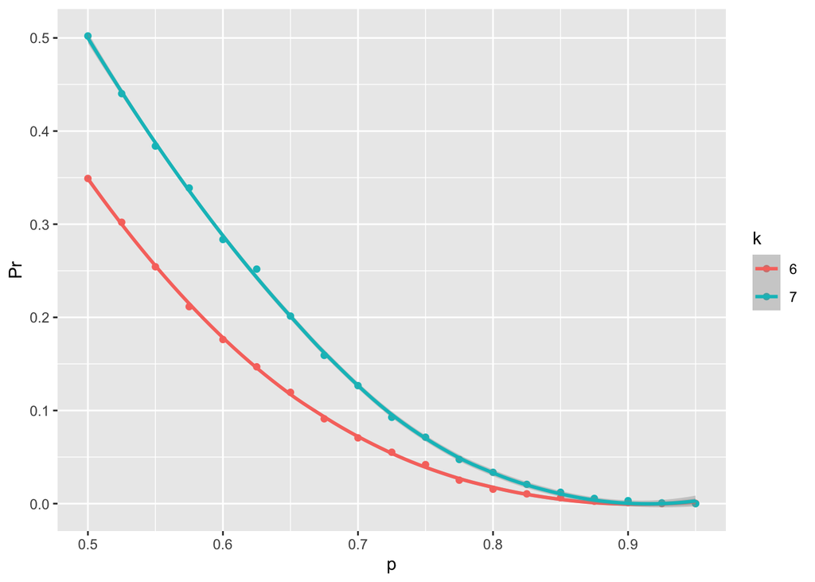

```r
library(ggplot2)
library(tibble)
prob_win <- function(p){
   B <- 10000
   result <- replicate(B, {
      b_win <- sample(c(1,0), 7, replace = TRUE, prob = c(1-p, p))
      sum(b_win)>=4
   })
   mean(result)
}
p <- seq(0.5, 0.95, 0.025)
Pr2 <- sapply(p,prob_win)
#qplot(p,Pr)
k1 <- rep("6",length(p))
k0 <- rep("7",length(p))
Pr12 <- tibble(k=c(k1,k0),p=c(p,p),Pr=c(Pr1,Pr2))
qplot(p,Pr,data=Pr12,color=k,geom=c("point","smooth"))
```

### 13.1.13 Qn

> 13. Repeat the exercise above, but now keep the probability fixed at `p <- 0.75` and compute the probability for different series lengths: best of 1 game, 3 games, 5 games,… Specifically, `N <- seq(1, 25, 2)`. Hint: use this function:

>     ```r
>     prob_win <- function(N, p=0.75){
>     B <- 10000
>     result <- replicate(B, {
>       b_win <- sample(c(1,0), N, replace = TRUE, prob = c(1-p, p))
>         sum(b_win)>=(N+1)/2
>       })
>     mean(result)
>     }
>     ```

Similarly, in the following simulation the probability of $p=0.6$ is assumed in order to be able to compare the results with previous questions. For a weaker team the chances of winning a series with more games reduces strongly.

```r
prob_win <- function(N, p=0.6){
   B <- 10000
   result <- replicate(B, {
      b_win <- sample(c(1,0), N, replace = TRUE, prob = c(1-p, p))
      sum(b_win)>=(N+1)/2
   })
   mean(result)
}
#prob_win(7)
N <- seq(1, 25, 2)
Pr1 <- sapply(N,prob_win)
```

For sake of completenss, here the chart for p=0.75.

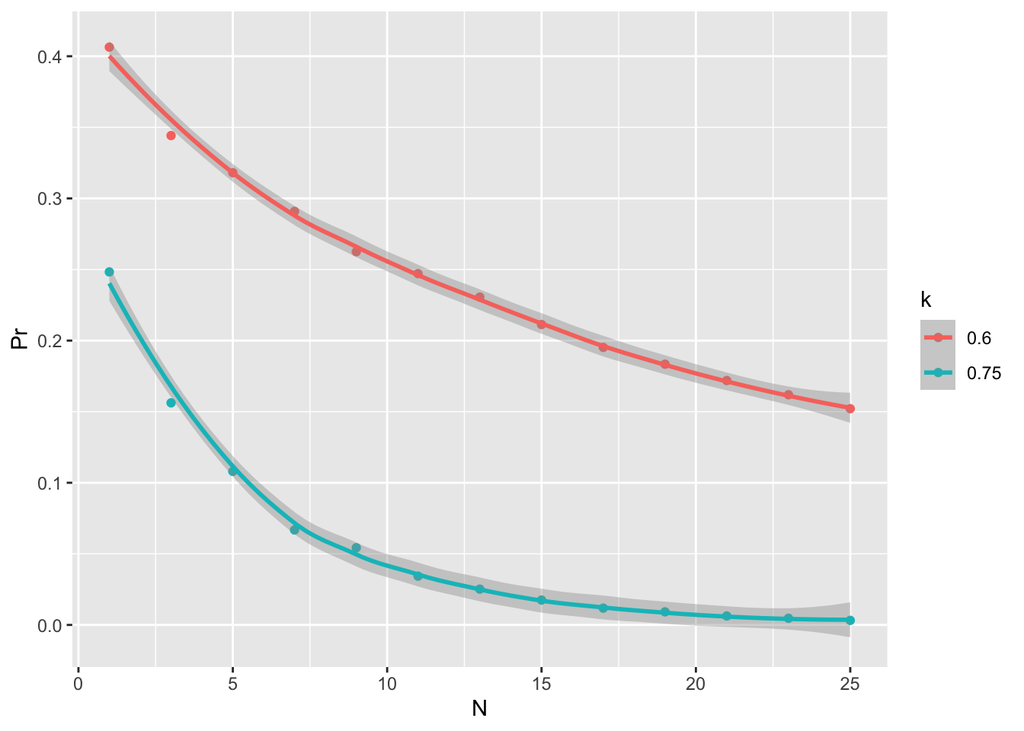

```r
prob_win <- function(N, p=0.75){
   B <- 10000
   result <- replicate(B, {
      b_win <- sample(c(1,0), N, replace = TRUE, prob = c(1-p, p))
      sum(b_win)>=(N+1)/2
   })
   mean(result)
}
N <- seq(1, 25, 2)
Pr2 <- sapply(N,prob_win)
k1 <- rep("0.6",length(N))
k0 <- rep("0.75",length(N))
Pr12 <- tibble(k=c(k1,k0),N=c(N,N),Pr=c(Pr1,Pr2))
qplot(N,Pr,data=Pr12,color=k,geom=c("point","smooth"))
```

## 13.2 Exercises Continuous Probability

### 13.2.1 Qn

> 1. Assume the distribution of female heights is approximated by a normal distribution with a mean of 64 inches and a standard deviation of 3 inches. If we pick a female at random, what is the probability that she is 5 feet or shorter?

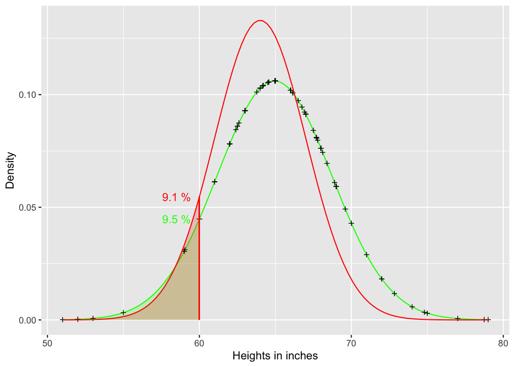

```r
library(magrittr)
library(ggplot2)
library(dslabs)
library(dplyr)
data(heights)
df <- heights %>% filter(sex == "Female")
x <- df %>% pull(height)
a <- 60
sh <-3
mh <- 64
dh <- dnorm(a,mh,sh)
ph <- pnorm(a,mh,sh)
prh <- round(ph,3)*100
m <- mean(x)
s <- sd(x)
d <- dnorm(a,m,s)
p <- pnorm(a,m,s)
pr <- round(p,3)*100
xm <- seq(min(x),max(x),.1)
ym <- dnorm(xm,m,s)
dfm <- tibble(height=xm, density=ym)
ggplot(df,aes(height)) +
  #geom_density() +
  #geom_histogram(aes(y=..density..),bins=25, alpha=.5, position="dodge", colour = "black") +
  stat_function(fun = dnorm, args = list(mean = m, sd = s), color="green") +
  geom_point(aes(y=dnorm(x,m,s)),shape=3, color="black", size=1.2) +
  #geom_segment(aes(x = a, y = 0.0, xend = a, yend = d), color="green",size=1) +
  annotate("text", x = a-1.5, y = d, label = paste(c(pr,"%"), collapse = " "),color="green") +
  geom_ribbon(data=subset(dfm,height<=a),aes(ymin=0,ymax=dnorm(height,m,s)),fill="green", alpha=0.2) +
  geom_segment(aes(x = a, y = 0.0, xend = a, yend = d), color="green",size=0.5) +
  stat_function(fun = dnorm, args = list(mean = mh, sd = sh), color="red") +
  geom_ribbon(data=subset(dfm,height<=a),aes(ymin=0,ymax=dnorm(height,mh,sh)),fill="red", alpha=0.2)+
  geom_segment(aes(x = a, y = 0.0, xend = a, yend = dh), color="red",size=0.5) +
  annotate("text", x = a-1.5, y = dh, label = paste(c(prh,"%"), collapse = " "),color="red") +
  ylab("Density") + xlab("Heights in inches")
```

In order to compute the probability that a randomly picked value will be within the red area and below the percentile of 9%, the empirical distribution function is utilized. Using the function $\mbox{mean}(x<=a)$ and the actual data set, yields a value of 8.8%. That means, by picking a female at random the probability that she will be 60 inches (5 feet) or shorter is about 9%.  
Using the normal distribution $\mbox{pnorm}(x,m,s)$ with $m:=64$ and $s:=3$ yields a slightly overestimated value of 9.1%. However using the mean $m:=64.9$ and standard deviation $s:=3.7$ of the `heights` data set yields an even larger overestimation of the original value of 9.4%.

```r
library(dslabs)
data(heights)
x <- heights %>% filter(sex=="Female") %>% pull
F <- function(a) mean(x<=a)
a <- 60
#reference
F(a)
```

```
## [1] 0.08823529
```

```r
m<-64
s<-3
pnorm(a, m, s)
```

```
## [1] 0.09121122
```

```r
m <- mean(x)
s <- sd(x)
pnorm(a, m, s)
```

```
## [1] 0.09451611
```

In this calculation it is not necessary to subtract the probability of `1` i.e. `1-F(a)`, because the question asked for the probability according to the definition of the empirical density function `mean(x<=a)`. That is, the probability of all values of `x` that are smaller or equal to `a`, here 60 inches. If it is asked for all values `x` that are larger than `a` as in the book, then the probability needs to be subtracted of `1`, in order to get the inverse value.

```r
library(dslabs)
library(magrittr)
library(tibble)
data(heights)
x <- heights %>% filter(sex=="Female") %>% pull
F <- function(a) mean(x<=a)
a <- 60
F(a)
```

```
## [1] 0.08823529
```

```r
sx<-sort(x)
xa <- tibble(sx,true=sx<=a) %>% filter(sx<=a) %>% pull(true)
length(xa)/length(x)
```

```
## [1] 0.08823529
```

From a discrete perspective the function `F(a)` can also be reproduced by looking at the number of total values available in the data set of female heights, which is 238 (length of the vector `x`). The number of values, which are smaller than `a=60` is 21 (length of vector ax). The ratio of these two values is exactly `F(a)`, because this is the definition of the function `F(a)=mean(x<=a)`.

### 13.2.2 Qn

> 2. Assume the distribution of female heights is approximated by a normal distribution with a mean of 64 inches and a standard deviation of 3 inches. If we pick a female at random, what is the probability that she is 6 feet or taller?

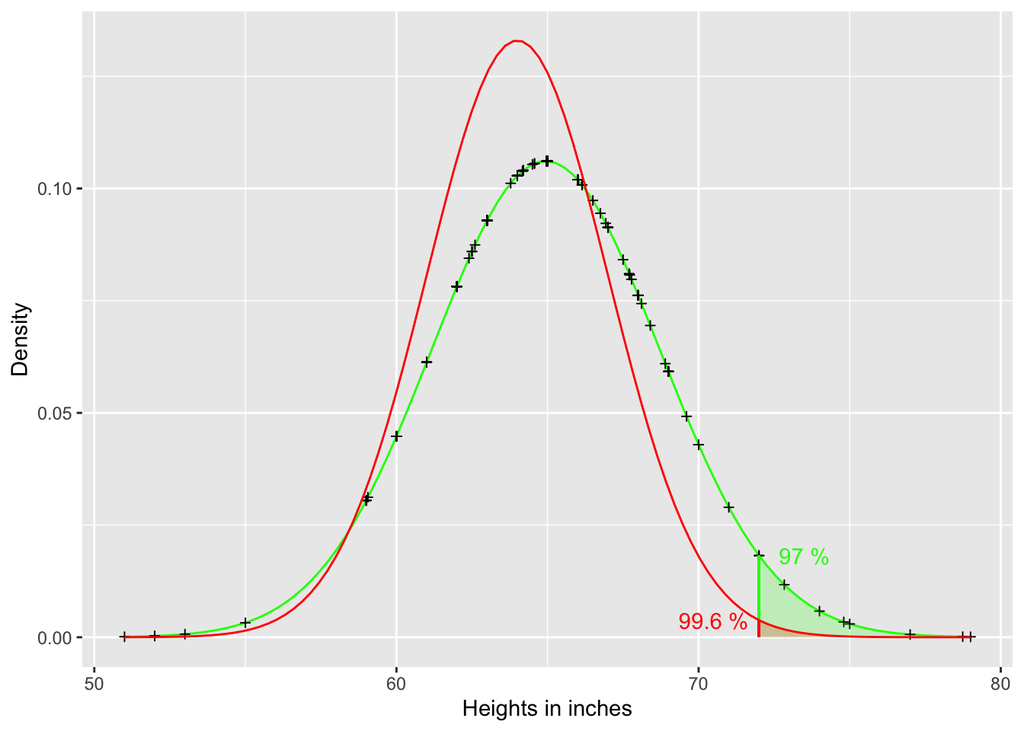

```r
library(tidyverse)
library(ggplot2)
library(dslabs)
data(heights)
df <- heights %>% filter(sex == "Female")
x <- df %>% pull(height)
a <- 72
sh <-3
mh <- 64
dh <- dnorm(a,mh,sh)
ph <- pnorm(a,mh,sh)
prh <- round(ph,3)*100
m <- mean(x)
s <- sd(x)
d <- dnorm(a,m,s)
p <- pnorm(a,m,s)
pr <- round(p,3)*100
xm <- seq(min(x),max(x),.1)
ym <- dnorm(xm,m,s)
dfm <- tibble(height=xm, density=ym)
#qplot(x,d)
ggplot(df,aes(height)) +
  #geom_density() +
  #geom_histogram(aes(y=..density..),bins=25, alpha=.5, position="dodge", colour = "black") +
  stat_function(fun = dnorm, args = list(mean = m, sd = s), color="green") +
  geom_point(aes(y=dnorm(x,m,s)),shape=3, color="black", size=1.2) +
  geom_segment(aes(x = a, y = 0.0, xend = a, yend = d), color="green",size=0.5) +
  annotate("text", x = a+1.5, y = d, label = paste(c(pr,"%"), collapse = " "),color="green") +
  geom_ribbon(data=subset(dfm,height>=a),aes(ymin=0,ymax=dnorm(height,m,s)),fill="green", alpha=0.2) +
  stat_function(fun = dnorm, args = list(mean = mh, sd = sh), color="red") +
  geom_ribbon(data=subset(dfm,height>=a),aes(ymin=0,ymax=dnorm(height,mh,sh)),fill="red", alpha=0.2)+
  geom_segment(aes(x = a, y = 0.0, xend = a, yend = dh), color="blue",size=0.5) +
  annotate("text", x = a-1.5, y = dh, label = paste(c(prh,"%"), collapse = " "),color="red") +
  geom_segment(aes(x = a, y = 0.0, xend = a, yend = dh), color="red",size=0.5) +
  ylab("Density") + xlab("Heights in inches")
```

For this question the same conditions apply as for the previous question with $m:=64$ and $s:=3$. Using the definition of 1 foot is 12 inches one gets for 6 feet 72 inches.

```r
library(tidyverse)
library(dslabs)
data(heights)
x <- heights %>% filter(sex=="Female") %>% pull
F <- function(a) mean(x<=a)
1 - F(72)
```

```
## [1] 0.02941176
```

```r
m<-64
s<-3
1 - pnorm(72, m, s)
```

```
## [1] 0.003830381
```

```r
1 - pnorm(72, mean(x), sd(x))
```

```
## [1] 0.03022582
```

### 13.2.3 Qn

> 3. Assume the distribution of female heights is approximated by a normal distribution with a mean of 64 inches and a standard deviation of 3 inches. If we pick a female at random, what is the probability that she is between 61 and 67 inches?

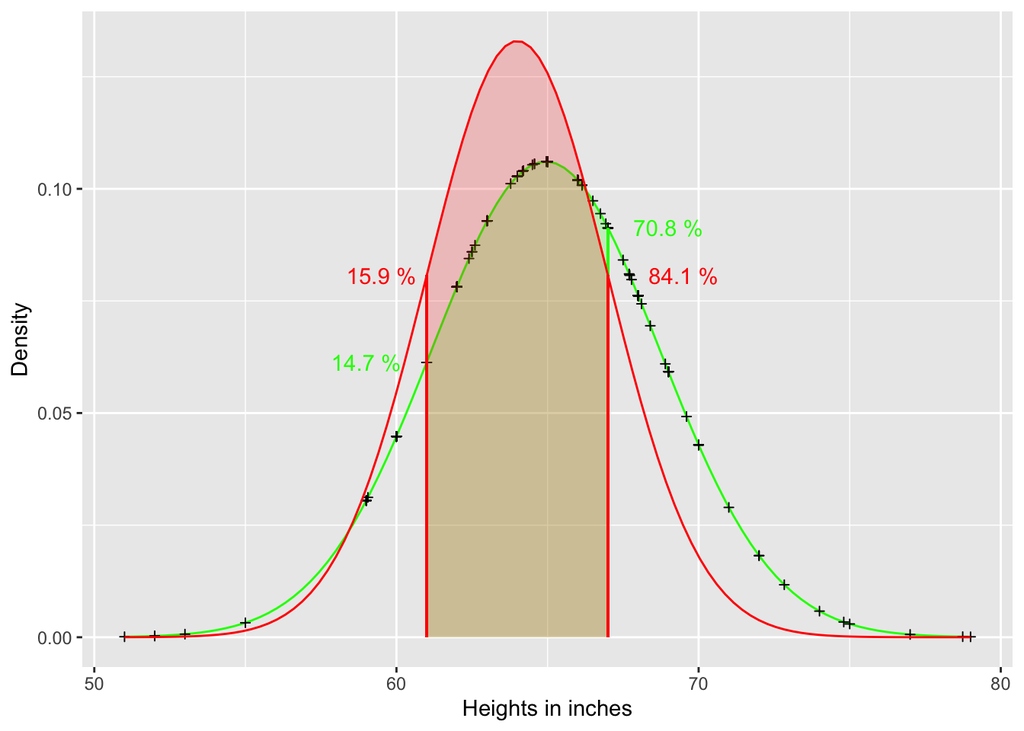

```r
library(magrittr)
library(ggplot2)
library(dslabs)
data(heights)
df <- heights %>% filter(sex == "Female")
x <- df %>% pull(height)
a <- 67
b <- 61
sh <-3
mh <- 64
m <- mean(x)
s <- sd(x)
d <- dnorm(a,m,s)
p <- pnorm(a,m,s)
dh <- dnorm(a,mh,sh)
ph <- pnorm(a,mh,sh)
db <- dnorm(b,m,s)
pb <- pnorm(b,m,s)
dbh <- dnorm(b,mh,sh)
pbh <- pnorm(b,mh,sh)
pr <- round(p,3)*100
prb <- round(pb,3)*100
prh <- round(ph,3)*100
prbh <- round(pbh,3)*100
xm <- seq(min(x),max(x),.1)
ym <- dnorm(xm,m,s)
dfm <- tibble(height=xm, density=ym)
ggplot(df,aes(height)) +
  #geom_density() +
  #geom_histogram(aes(y=..density..),bins=25, alpha=.5, position="dodge", colour = "black") +
  stat_function(fun = dnorm, args = list(mean = m, sd = s), color="green") +
  geom_point(aes(y=dnorm(x,m,s)),shape=3, color="black", size=1.2) +
  geom_segment(aes(x = a, y = 0.0, xend = a, yend = d), color="green",size=0.5) +
  geom_segment(aes(x = b, y = 0.0, xend = b, yend = db), color="green",size=0.5) +
  annotate("text", x = a+2, y = d, label = paste(c(pr,"%"), collapse = " "),color="green") +
  annotate("text", x = b-2, y = db, label = paste(c(prb,"%"), collapse = " "),color="green") +
  geom_ribbon(data=subset(dfm,height<=a & height>=b), aes(ymin=0,ymax=dnorm(height,m,s)),fill="green", alpha=0.2)+
  #geom_ribbon(data=subset(dfm,height<=b), aes(ymin=0,ymax=dnorm(height,m,s)),fill="red", alpha=0.2)+
  #geom_ribbon(data=subset(dfm,height>=a),aes(ymin=0,ymax=dnorm(height,m,s)),fill="red", alpha=0.2) +
  stat_function(fun = dnorm, args = list(mean = mh, sd = sh), color="red") +
  geom_ribbon(data=subset(dfm,height<=a & height>=b), aes(ymin=0,ymax=dnorm(height,mh,sh)),fill="red", alpha=0.2)+
  annotate("text", x = a+2.5, y = dh, label = paste(c(prh,"%"), collapse = " "),color="red") +
  annotate("text", x = b-1.5, y = dbh, label = paste(c(prbh,"%"), collapse = " "),color="red") +
  geom_segment(aes(x = a, y = 0.0, xend = a, yend = dh), color="red",size=0.5) +
  geom_segment(aes(x = b, y = 0.0, xend = b, yend = dbh), color="red",size=0.5) +
  ylab("Density") + xlab("Heights in inches")
```

```r
library(tidyverse)
library(dslabs)
data(heights)
x <- heights %>% filter(sex=="Female") %>% pull
F <- function(a) mean(x<=a)
F(67) - F(61)
```

```
## [1] 0.6554622
```

```r
m<-64
s<-3
pnorm(67, m, s) - pnorm(61, m, s)
```

```
## [1] 0.6826895
```

```r
a<-(61-m)/s
b<-(67-m)/s
c<-(60-m)/s
pnorm(67, mean(x), sd(x))-pnorm(61, mean(x), sd(x))
```

```
## [1] 0.5607038
```

### 13.2.4 Qn

> 4. Repeat the exercise above, but convert everything to centimeters. That is, multiply every height, including the standard deviation, by 2.54. What is the answer now?

The unity of the values is just a scaling factor, which will not change the probabilities, because it is canceled out by the subtraction. That is why the answer is the same as in the question before.

```r
library(tidyverse)
library(dslabs)
data(heights)
x <- heights %>% filter(sex=="Female") %>% pull
x<- x*2.54
F <- function(a) mean(x<=a)
F(67*2.54) - F(61*2.54)
```

```
## [1] 0.6554622
```

```r
m<-64*2.54
s<-3*2.54
pnorm(67*2.54, m, s) - pnorm(61*2.54, m, s)
```

```
## [1] 0.6826895
```

### 13.2.5 Qn

> 5. Notice that the answer to the question does not change when you change units. This makes sense since the answer to the question should not be affected by what units we use. In fact, if you look closely, you notice that 61 and 67 are both 1 SD away from the average. Compute the probability that a randomly picked, normally distributed random variable is within 1 SD from the average.

(typo in question 64=>67)

```r
m<-64
s<-3
pnorm(m+s, m, s) - pnorm(m-s, m, s)
```

```
## [1] 0.6826895
```

### 13.2.6 Qn

> 6. To see the math that explains why the answers to questions 3, 4, and 5 are the same, suppose we have a random variable with average $m$ and standard error $s$. Suppose we ask the probability of $X$ being smaller or equal to $a$. Remember, that by definition, $a$ is $(a - m)/s$ standard deviations $s$ away from the average $m$. The probability is:

>    $$\mbox{Pr}(X \leq a)$$

>    Now we subtract $m$ to both sides and then divide both sides by $s$:

>    $$\mbox{Pr}\left(\frac{X-m}{s} \leq \frac{a-m}{s} \right)$$

>    The quantity on the left is a standard normal random variable. It has an average of 0 and a standard error of 1. We will call it $Z$:

>    $$\mbox{Pr}\left(Z \leq \frac{a-m}{s} \right)$$

>    So, no matter the units, the probability of $X\leq a$ is the same as the probability of a standard normal variable being less than $(a - m)/s$. If $m$ is the average and $s$ the standard error, which of the following R code would give us the right answer in every situation:

>    A. `mean(X<=a)`

>    B. `pnorm((a - m)/s)`

>    C. `pnorm((a - m)/s, m, s)`

>    D. `pnorm(a)`

Answer: B. (replaced $\mu$ with $m$ and $\sigma$ with $s$)
The Theory behind is to understand the difference between normal distribution and standard normal distribution. The R code `pnorm((a-m)/s)` standardizes the value a. It removes the units and transforms the value from the normal distribution to the standard normal distribution.
$$\mbox{Pr}\left(Z \leq \frac{a-m}{s} \right) = \mbox{Pr}\left(Z \leq z \right)$$
The lowercase letter z is defined as $z:=\frac{a-m}{s}$ and called the `z-transform`. The code from answer A is the definition of the empirical normal distribution function $F(a)=\mbox{mean}(X<=a)$.

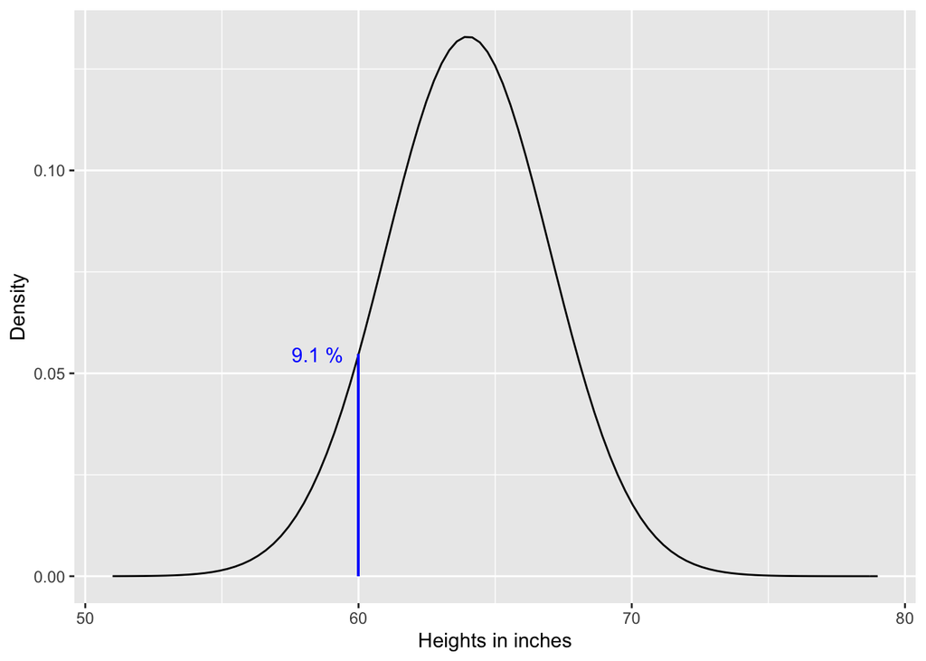

```r
library(magrittr)
library(ggplot2)
library(dslabs)
data(heights)
df <- heights %>% filter(sex == "Female")
x <- df %>% pull(height)
a <- 60
sh <-3
mh <- 64
dh <- dnorm(a,mh,sh)
ph <- pnorm(a,mh,sh)
prh <- round(ph,3)*100
ggplot(df,aes(height)) +
  stat_function(fun = dnorm, args = list(mean = mh, sd = sh), color="black") +
  geom_segment(aes(x = a, y = 0.0, xend = a, yend = dh), color="blue",size=0.5) +
  annotate("text", x = a-1.5, y = dh, label = paste(c(prh,"%"), collapse = " "),color="blue") +
  ylab("Density") + xlab("Heights in inches")
```

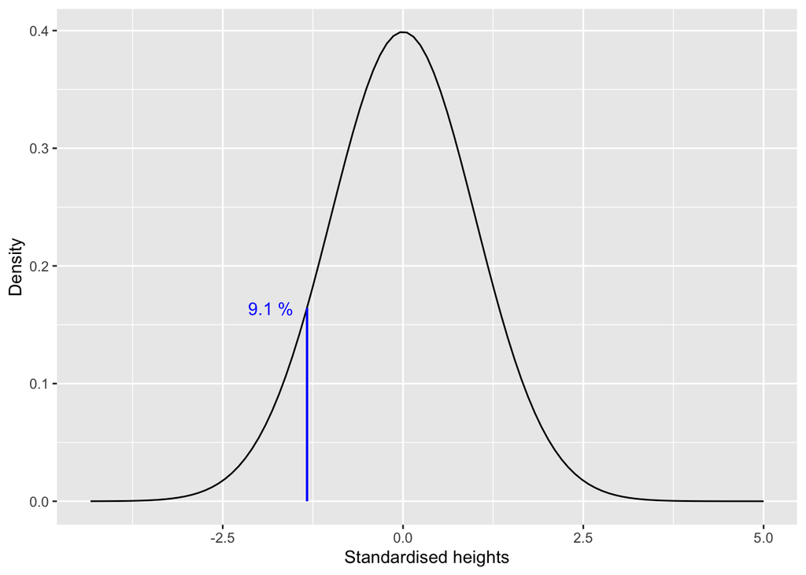

```r
library(magrittr)
library(ggplot2)
library(dslabs)
data(heights)
df <- heights %>% filter(sex == "Female")
x <- df %>% pull(height)
a <- 60
sh <-3
mh <- 64
as <- (a-mh)/sh
dfs <- tibble(sex="Female", height=(df$height-mh)/sh)
dh <- dnorm(as,0,1)
ph <- pnorm(as,0,1)
prh <- round(ph,3)*100
ggplot(dfs,aes(height)) +
  stat_function(fun = dnorm, args = list(mean = 0, sd = 1), color="black") +
  geom_segment(aes(x = as, y = 0.0, xend = as, yend = dh), color="blue",size=0.5) +
  annotate("text", x = as-0.5, y = dh, label = paste(c(prh,"%"), collapse = " "),color="blue") +
  ylab("Density") + xlab("Standardised heights")
```

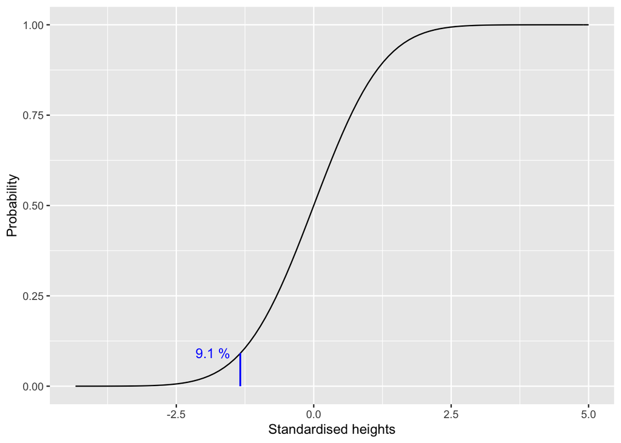

```r
library(magrittr)
library(ggplot2)
library(dslabs)
data(heights)
df <- heights %>% filter(sex == "Female")
x <- df %>% pull(height)
a <- 60
sh <-3
mh <- 64
as <- (a-mh)/sh
dfs <- tibble(sex="Female", height=(df$height-mh)/sh)
ph <- pnorm(as,0,1)
prh <- round(ph,3)*100
ggplot(dfs,aes(height)) +
  stat_function(fun = pnorm, args = list(mean = 0, sd = 1), color="black") +
  geom_segment(aes(x = as, y = 0.0, xend = as, yend = ph), color="blue",size=0.5) +
  annotate("text", x = as-0.5, y = ph, label = paste(c(prh,"%"), collapse = " "),color="blue") +
  ylab("Probability") + xlab("Standardised heights")
```

```r
m<-64
s<-3
a<-60
z <- (a-m)/s
pnorm(a, m, s)
```

```
## [1] 0.09121122
```

```r
#=> normal distribution (ND)
mean(x<=a)
```

```
## [1] 0.08823529
```

```r
#=> standard normal distribution (SND)
pnorm(z)
```

```
## [1] 0.09121122
```

```r
#=> value of (a-m)/s=-1.3 in ND is far left, therefore close to zero
pnorm(z, m, s)
```

```
## [1] 1.884582e-105
```

```r
#=> for large values of a (i.e. >3) the percentile will be sero, but the probability will be 1, because the SND is normalized to 1
pnorm(a)
```

```
## [1] 1
```

### 13.2.7 Qn

> 7. Imagine the distribution of male adults is approximately normal with an expected value of 69 and a standard deviation of 3. How tall is the male in the 99th percentile? Hint: use `qnorm`.

Depending on the mean and standard deviation the value for the 99th percentile is 78 or 76 inch.

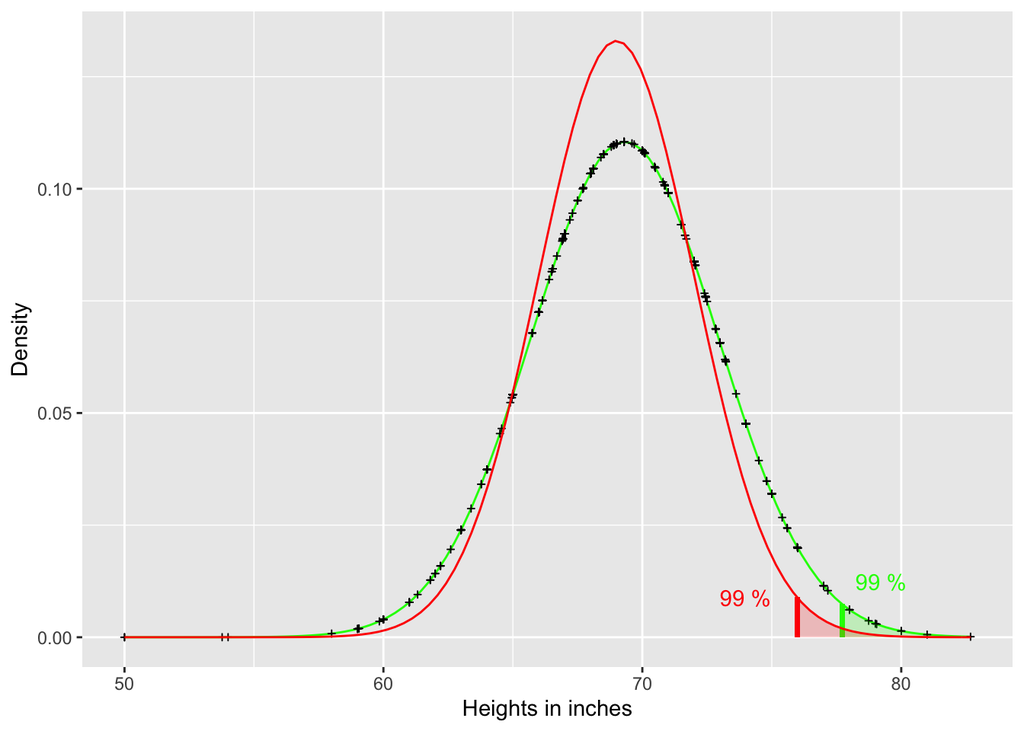

```r
library(magrittr)
library(ggplot2)
library(dslabs)
data(heights)
df <- heights %>% filter(sex == "Male")
x <- df %>% pull(height)
a <- 77.71525
ah <- 75.97904
sh <-3
mh <- 69
m <- mean(x)
s <- sd(x)
d <- dnorm(a,m,s)
p <- pnorm(a,m,s)
pr <- round(p,3)*100
dh <- dnorm(ah,mh,sh)
ph <- pnorm(ah,mh,sh)
prh <- round(ph,3)*100
xm <- seq(min(x),max(x),.1)
ym <- dnorm(xm,m,s)
dfm <- tibble(height=xm, density=ym)
ggplot(df,aes(height)) +
  #geom_density() +
  #geom_histogram(aes(y=..density..),bins=25, alpha=.5, position="dodge", colour = "black") +
  stat_function(fun = dnorm, args = list(mean = m, sd = s), color="green") +
  geom_point(aes(y=dnorm(x,m,s)),shape=3, color="black", size=0.8) +
  geom_segment(aes(x = a, y = 0.0, xend = a, yend = d), color="green",size=1) +
  annotate("text", x = a+1.5, y = d+0.005, label = paste(c(pr,"%"), collapse = " "),color="green") +
  geom_ribbon(data=subset(dfm,height>=a),aes(ymin=0,ymax=dnorm(height,m,s)),fill="green", alpha=0.2) +
  # RED
  stat_function(fun = dnorm, args = list(mean = mh, sd = sh), color="red") +
  geom_ribbon(data=subset(dfm,height>=ah),aes(ymin=0,ymax=dnorm(height,mh,sh)),fill="red", alpha=0.2)+
  geom_segment(aes(x = ah, y = 0.0, xend = ah, yend = dh), color="red",size=1) +annotate("text", x = ah-2, y = dh, label = paste(c(prh,"%"), collapse = " "),color="red") +
  ylab("Density") + xlab("Heights in inches")
```

```r
library(magrittr)
library(ggplot2)
library(dslabs)
data(heights)
df <- heights %>% filter(sex == "Male")
x <- df %>% pull(height)
mh<-69
sh<-3
u<-c(0.99)
qnorm(u,mh,sh)
```

```
## [1] 75.97904
```

```r
m <- mean(x)
s <- sd(x)
qnorm(u,m,s)
```

```
## [1] 77.71525
```

```r
# reference
x <- heights %>% filter(sex=="Male") %>% pull
F <- function(a) mean(x<=a)
F(75.97904)
```

```
## [1] 0.9704433
```

```r
F(77.71525)
```

```
## [1] 0.9864532
```

### 13.2.8 Qn

> 8. The distribution of IQ scores is approximately normally distributed. The average is 100 and the standard deviation is 15. Suppose you want to know the distribution of the highest IQ across all graduating classes if 10,000 people are born each in your school district. Run a Monte Carlo simulation with `B=1000` generating 10,000 IQ scores and keeping the highest. Make a histogram.

In order to generate a random sample that is normally distributed the function `rnorm` is used. First, a sample of the requested 10,000 random values are provided as input into the function along with the defined mean of 100 and standard deviation of 15. From the result the largest value is extracted. This procedure is repeated 1,000 times. After these thousand experiments, in which 10,000 individuals were generated the new mean (=158) and standard deviation (=5) is computed.  
The mean for this new distribution of the individuals with the highest IQ in their population is about 60% larger than the average population. In addition, the rather small standard deviation of only 5 indicates that most of the individuals have similar IQ values around the mean of 158. The result that a population with individuals having a high IQ value results in a narrow standard deviation might account for the he saying “Great minds think alike”.  
For the plot, the resulted IQ values are transformed into density distribution values using the `dnorm` function. Finally the plot is constructed with `stat_function` and `geom_histogram`.

```r
library(ggplot2)
library(magrittr)
library(tibble)
m<-100
s<-15
B<-1000
rpop<-replicate(B,max(rnorm(10000,m,s)))
mr<-mean(rpop)
mr
```

```
## [1] 157.9491
```

```r
sr<-sd(rpop)
sr
```

```
## [1] 4.773138
```

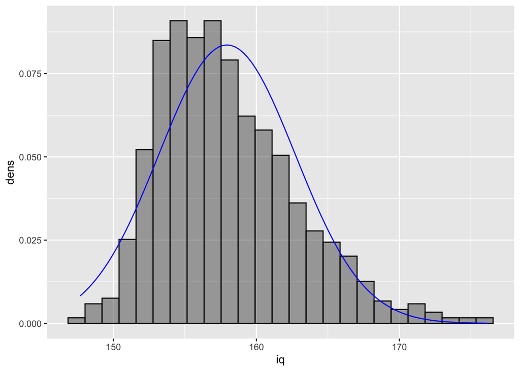

```r
dpop<-dnorm(rpop,mr,sr)
tpop <- tibble(iq=rpop,dens=dpop)
ggplot(tpop,aes(iq,dens)) +
  geom_histogram(aes(y=..density..),bins=25, alpha=.5, position="dodge", color="black") +
  stat_function(fun = dnorm, args = list(mean = mr, sd = sr), color="blue")
```